# 1. Import the datasets and libraries, check datatype, statistical summary, shape, null values or incorrect imputation. (5 marks)

Overview

Dataset info

| Number of variables | 14 |
| --- | --- |
| Number of observations | 5000 |
| Total Missing (%) | 0.0% |
| Total size in memory | 547.0 KiB |
| Average record size in memory | 112.0 B |

Variables types

| Numeric | 8 |
| --- | --- |
| Categorical | 0 |
| Boolean | 5 |
| Date | 0 |
| Text (Unique) | 0 |
| Rejected | 1 |
| Unsupported | 0 |

Warnings

- `Experience` is highly correlated with `Age` (ρ = 0.97718) Rejected

- `CCAvg` has 106 / 2.1% zeros Zeros

- `Mortgage` has 3462 / 69.2% zeros Zeros

Variables

ID  
Numeric

| Distinct count | 5000 |
| --- | --- |
| Unique (%) | 100.0% |
| Missing (%) | 0.0% |
| Missing (n) | 0 |
| Infinite (%) | 0.0% |
| Infinite (n) | 0 |

| Mean | 2500.5 |
| --- | --- |
| Minimum | 1 |
| Maximum | 5000 |
| Zeros (%) | 0.0% |

Toggle details

**Statistics**

Quantile statistics

| Minimum | 1 |
| --- | --- |
| 5-th percentile | 250.95 |
| Q1 | 1250.8 |
| Median | 2500.5 |
| Q3 | 3750.2 |
| 95-th percentile | 4750.1 |
| Maximum | 5000 |
| Range | 4999 |
| Interquartile range | 2499.5 |

Descriptive statistics

| Standard deviation | 1443.5 |
| --- | --- |
| Coef of variation | 0.57729 |
| Kurtosis | -1.2 |
| Mean | 2500.5 |
| MAD | 1250 |
| Skewness | 0 |
| Sum | 12502500 |
| Variance | 2083800 |
| Memory size | 39.2 KiB |

**Histogram**

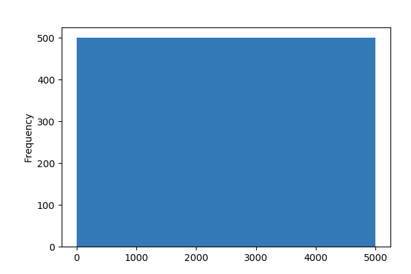

**Common Values**

| Value | Count | Frequency (%) |  |
| --- | --- | --- | --- |
| 2047 | 1 | 0.0% |  |
| 2608 | 1 | 0.0% |  |
| 4647 | 1 | 0.0% |  |
| 2600 | 1 | 0.0% |  |
| 553 | 1 | 0.0% |  |
| 4651 | 1 | 0.0% |  |
| 2604 | 1 | 0.0% |  |
| 557 | 1 | 0.0% |  |
| 4655 | 1 | 0.0% |  |
| 561 | 1 | 0.0% |  |
| Other values (4990) | 4990 | 99.8% |  |

**Extreme Values**

Minimum 5 values

| Value | Count | Frequency (%) |  |
| --- | --- | --- | --- |
| 1 | 1 | 0.0% |  |
| 2 | 1 | 0.0% |  |
| 3 | 1 | 0.0% |  |
| 4 | 1 | 0.0% |  |
| 5 | 1 | 0.0% |  |

Maximum 5 values

| Value | Count | Frequency (%) |  |
| --- | --- | --- | --- |
| 4996 | 1 | 0.0% |  |
| 4997 | 1 | 0.0% |  |
| 4998 | 1 | 0.0% |  |
| 4999 | 1 | 0.0% |  |
| 5000 | 1 | 0.0% |  |

Age  
Numeric

| Distinct count | 45 |
| --- | --- |
| Unique (%) | 0.9% |
| Missing (%) | 0.0% |
| Missing (n) | 0 |
| Infinite (%) | 0.0% |
| Infinite (n) | 0 |

| Mean | 45.338 |
| --- | --- |
| Minimum | 23 |
| Maximum | 67 |
| Zeros (%) | 0.0% |

Toggle details

**Statistics**

Quantile statistics

| Minimum | 23 |
| --- | --- |
| 5-th percentile | 27 |
| Q1 | 35 |
| Median | 45 |
| Q3 | 55 |
| 95-th percentile | 63 |
| Maximum | 67 |
| Range | 44 |
| Interquartile range | 20 |

Descriptive statistics

| Standard deviation | 11.463 |
| --- | --- |
| Coef of variation | 0.25284 |
| Kurtosis | -1.1531 |
| Mean | 45.338 |
| MAD | 9.903 |
| Skewness | -0.029341 |
| Sum | 226692 |
| Variance | 131.4 |
| Memory size | 39.2 KiB |

**Histogram**

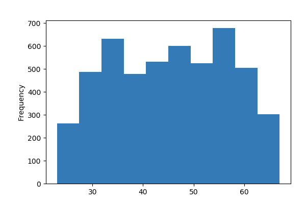

**Common Values**

| Value | Count | Frequency (%) |  |
| --- | --- | --- | --- |
| 35 | 151 | 3.0% |  |
| 43 | 149 | 3.0% |  |
| 52 | 145 | 2.9% |  |
| 58 | 143 | 2.9% |  |
| 54 | 143 | 2.9% |  |
| 50 | 138 | 2.8% |  |
| 41 | 136 | 2.7% |  |
| 30 | 136 | 2.7% |  |
| 56 | 135 | 2.7% |  |
| 34 | 134 | 2.7% |  |
| Other values (35) | 3590 | 71.8% |  |

**Extreme Values**

Minimum 5 values

| Value | Count | Frequency (%) |  |
| --- | --- | --- | --- |
| 23 | 12 | 0.2% |  |
| 24 | 28 | 0.6% |  |
| 25 | 53 | 1.1% |  |
| 26 | 78 | 1.6% |  |
| 27 | 91 | 1.8% |  |

Maximum 5 values

| Value | Count | Frequency (%) |  |
| --- | --- | --- | --- |
| 63 | 108 | 2.2% |  |
| 64 | 78 | 1.6% |  |
| 65 | 80 | 1.6% |  |
| 66 | 24 | 0.5% |  |
| 67 | 12 | 0.2% |  |

Experience  
Highly correlated

*This variable is highly correlated with `Age` and should be ignored for analysis*

| Correlation | 0.97718 |
| --- | --- |

Income  
Numeric

| Distinct count | 162 |
| --- | --- |
| Unique (%) | 3.2% |
| Missing (%) | 0.0% |
| Missing (n) | 0 |
| Infinite (%) | 0.0% |
| Infinite (n) | 0 |

| Mean | 73.774 |
| --- | --- |
| Minimum | 8 |
| Maximum | 224 |
| Zeros (%) | 0.0% |

Toggle details

**Statistics**

Quantile statistics

| Minimum | 8 |
| --- | --- |
| 5-th percentile | 18 |
| Q1 | 39 |
| Median | 64 |
| Q3 | 98 |
| 95-th percentile | 170 |
| Maximum | 224 |
| Range | 216 |
| Interquartile range | 59 |

Descriptive statistics

| Standard deviation | 46.034 |
| --- | --- |
| Coef of variation | 0.62398 |
| Kurtosis | -0.044244 |
| Mean | 73.774 |
| MAD | 37.059 |
| Skewness | 0.84134 |
| Sum | 368871 |
| Variance | 2119.1 |
| Memory size | 39.2 KiB |

**Histogram**

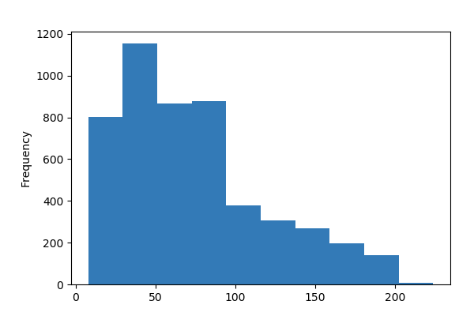

**Common Values**

| Value | Count | Frequency (%) |  |
| --- | --- | --- | --- |
| 44 | 85 | 1.7% |  |
| 38 | 84 | 1.7% |  |
| 81 | 83 | 1.7% |  |
| 41 | 82 | 1.6% |  |
| 39 | 81 | 1.6% |  |
| 40 | 78 | 1.6% |  |
| 42 | 77 | 1.5% |  |
| 83 | 74 | 1.5% |  |
| 43 | 70 | 1.4% |  |
| 45 | 69 | 1.4% |  |
| Other values (152) | 4217 | 84.3% |  |

**Extreme Values**

Minimum 5 values

| Value | Count | Frequency (%) |  |
| --- | --- | --- | --- |
| 8 | 23 | 0.5% |  |
| 9 | 26 | 0.5% |  |
| 10 | 23 | 0.5% |  |
| 11 | 27 | 0.5% |  |
| 12 | 30 | 0.6% |  |

Maximum 5 values

| Value | Count | Frequency (%) |  |
| --- | --- | --- | --- |
| 203 | 2 | 0.0% |  |
| 204 | 3 | 0.1% |  |
| 205 | 2 | 0.0% |  |
| 218 | 1 | 0.0% |  |
| 224 | 1 | 0.0% |  |

ZIP Code  
Numeric

| Distinct count | 467 |
| --- | --- |
| Unique (%) | 9.3% |
| Missing (%) | 0.0% |
| Missing (n) | 0 |
| Infinite (%) | 0.0% |
| Infinite (n) | 0 |

| Mean | 93153 |
| --- | --- |
| Minimum | 9307 |
| Maximum | 96651 |
| Zeros (%) | 0.0% |

Toggle details

**Statistics**

Quantile statistics

| Minimum | 9307 |
| --- | --- |
| 5-th percentile | 90073 |
| Q1 | 91911 |
| Median | 93437 |
| Q3 | 94608 |
| 95-th percentile | 95670 |
| Maximum | 96651 |
| Range | 87344 |
| Interquartile range | 2697 |

Descriptive statistics

| Standard deviation | 2121.9 |
| --- | --- |
| Coef of variation | 0.022778 |
| Kurtosis | 486.2 |
| Mean | 93153 |
| MAD | 1563.7 |
| Skewness | -12.5 |
| Sum | 465762515 |
| Variance | 4502300 |
| Memory size | 39.2 KiB |

**Histogram**

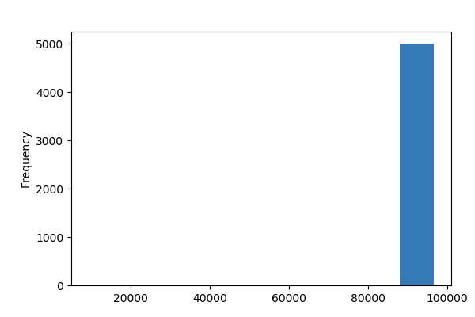

**Common Values**

| Value | Count | Frequency (%) |  |
| --- | --- | --- | --- |
| 94720 | 169 | 3.4% |  |
| 94305 | 127 | 2.5% |  |
| 95616 | 116 | 2.3% |  |
| 90095 | 71 | 1.4% |  |
| 93106 | 57 | 1.1% |  |
| 92037 | 54 | 1.1% |  |
| 93943 | 54 | 1.1% |  |
| 91320 | 53 | 1.1% |  |
| 91711 | 52 | 1.0% |  |
| 94025 | 52 | 1.0% |  |
| Other values (457) | 4195 | 83.9% |  |

**Extreme Values**

Minimum 5 values

| Value | Count | Frequency (%) |  |
| --- | --- | --- | --- |
| 9307 | 1 | 0.0% |  |
| 90005 | 5 | 0.1% |  |
| 90007 | 6 | 0.1% |  |
| 90009 | 8 | 0.2% |  |
| 90011 | 3 | 0.1% |  |

Maximum 5 values

| Value | Count | Frequency (%) |  |
| --- | --- | --- | --- |
| 96091 | 4 | 0.1% |  |
| 96094 | 2 | 0.0% |  |
| 96145 | 1 | 0.0% |  |
| 96150 | 4 | 0.1% |  |
| 96651 | 6 | 0.1% |  |

Family  
Numeric

| Distinct count | 4 |
| --- | --- |
| Unique (%) | 0.1% |
| Missing (%) | 0.0% |
| Missing (n) | 0 |
| Infinite (%) | 0.0% |
| Infinite (n) | 0 |

| Mean | 2.3964 |
| --- | --- |
| Minimum | 1 |
| Maximum | 4 |
| Zeros (%) | 0.0% |

Toggle details

**Statistics**

Quantile statistics

| Minimum | 1 |
| --- | --- |
| 5-th percentile | 1 |
| Q1 | 1 |
| Median | 2 |
| Q3 | 3 |
| 95-th percentile | 4 |
| Maximum | 4 |
| Range | 3 |
| Interquartile range | 2 |

Descriptive statistics

| Standard deviation | 1.1477 |
| --- | --- |
| Coef of variation | 0.47891 |
| Kurtosis | -1.4036 |
| Mean | 2.3964 |
| MAD | 1.0277 |
| Skewness | 0.15522 |
| Sum | 11982 |
| Variance | 1.3171 |
| Memory size | 39.2 KiB |

**Histogram**

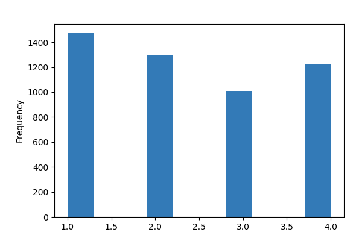

**Common Values**

| Value | Count | Frequency (%) |  |
| --- | --- | --- | --- |
| 1 | 1472 | 29.4% |  |
| 2 | 1296 | 25.9% |  |
| 4 | 1222 | 24.4% |  |
| 3 | 1010 | 20.2% |  |

**Extreme Values**

Minimum 5 values

| Value | Count | Frequency (%) |  |
| --- | --- | --- | --- |
| 1 | 1472 | 29.4% |  |
| 2 | 1296 | 25.9% |  |
| 3 | 1010 | 20.2% |  |
| 4 | 1222 | 24.4% |  |

Maximum 5 values

| Value | Count | Frequency (%) |  |
| --- | --- | --- | --- |
| 1 | 1472 | 29.4% |  |
| 2 | 1296 | 25.9% |  |
| 3 | 1010 | 20.2% |  |
| 4 | 1222 | 24.4% |  |

CCAvg  
Numeric

| Distinct count | 108 |
| --- | --- |
| Unique (%) | 2.2% |
| Missing (%) | 0.0% |
| Missing (n) | 0 |
| Infinite (%) | 0.0% |
| Infinite (n) | 0 |

| Mean | 1.9379 |
| --- | --- |
| Minimum | 0 |
| Maximum | 10 |
| Zeros (%) | 2.1% |

Toggle details

**Statistics**

Quantile statistics

| Minimum | 0 |
| --- | --- |
| 5-th percentile | 0.1 |
| Q1 | 0.7 |
| Median | 1.5 |
| Q3 | 2.5 |
| 95-th percentile | 6 |
| Maximum | 10 |
| Range | 10 |
| Interquartile range | 1.8 |

Descriptive statistics

| Standard deviation | 1.7477 |
| --- | --- |
| Coef of variation | 0.90181 |
| Kurtosis | 2.6467 |
| Mean | 1.9379 |
| MAD | 1.2805 |
| Skewness | 1.5984 |
| Sum | 9689.7 |
| Variance | 3.0543 |
| Memory size | 39.2 KiB |

**Histogram**

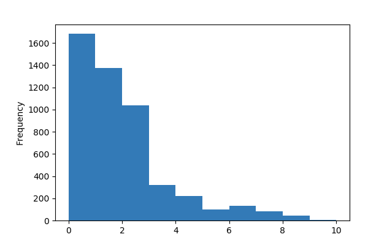

**Common Values**

| Value | Count | Frequency (%) |  |
| --- | --- | --- | --- |
| 0.3 | 241 | 4.8% |  |
| 1.0 | 231 | 4.6% |  |
| 0.2 | 204 | 4.1% |  |
| 2.0 | 188 | 3.8% |  |
| 0.8 | 187 | 3.7% |  |
| 0.1 | 183 | 3.7% |  |
| 0.4 | 179 | 3.6% |  |
| 1.5 | 178 | 3.6% |  |
| 0.7 | 169 | 3.4% |  |
| 0.5 | 163 | 3.3% |  |
| Other values (98) | 3077 | 61.5% |  |

**Extreme Values**

Minimum 5 values

| Value | Count | Frequency (%) |  |
| --- | --- | --- | --- |
| 0.0 | 106 | 2.1% |  |
| 0.1 | 183 | 3.7% |  |
| 0.2 | 204 | 4.1% |  |
| 0.3 | 241 | 4.8% |  |
| 0.4 | 179 | 3.6% |  |

Maximum 5 values

| Value | Count | Frequency (%) |  |
| --- | --- | --- | --- |
| 8.8 | 9 | 0.2% |  |
| 8.9 | 1 | 0.0% |  |
| 9.0 | 2 | 0.0% |  |
| 9.3 | 1 | 0.0% |  |
| 10.0 | 3 | 0.1% |  |

Education  
Numeric

| Distinct count | 3 |
| --- | --- |
| Unique (%) | 0.1% |
| Missing (%) | 0.0% |
| Missing (n) | 0 |
| Infinite (%) | 0.0% |
| Infinite (n) | 0 |

| Mean | 1.881 |
| --- | --- |
| Minimum | 1 |
| Maximum | 3 |
| Zeros (%) | 0.0% |

Toggle details

**Statistics**

Quantile statistics

| Minimum | 1 |
| --- | --- |
| 5-th percentile | 1 |
| Q1 | 1 |
| Median | 2 |
| Q3 | 3 |
| 95-th percentile | 3 |
| Maximum | 3 |
| Range | 2 |
| Interquartile range | 2 |

Descriptive statistics

| Standard deviation | 0.83987 |
| --- | --- |
| Coef of variation | 0.4465 |
| Kurtosis | -1.5461 |
| Mean | 1.881 |
| MAD | 0.73863 |
| Skewness | 0.22709 |
| Sum | 9405 |
| Variance | 0.70538 |
| Memory size | 39.2 KiB |

**Histogram**

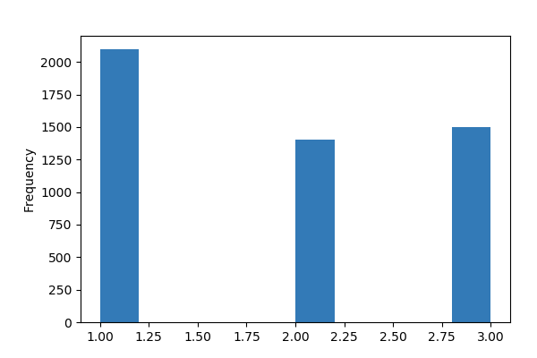

**Common Values**

| Value | Count | Frequency (%) |  |
| --- | --- | --- | --- |
| 1 | 2096 | 41.9% |  |
| 3 | 1501 | 30.0% |  |
| 2 | 1403 | 28.1% |  |

**Extreme Values**

Minimum 5 values

| Value | Count | Frequency (%) |  |
| --- | --- | --- | --- |
| 1 | 2096 | 41.9% |  |
| 2 | 1403 | 28.1% |  |
| 3 | 1501 | 30.0% |  |

Maximum 5 values

| Value | Count | Frequency (%) |  |
| --- | --- | --- | --- |
| 1 | 2096 | 41.9% |  |
| 2 | 1403 | 28.1% |  |
| 3 | 1501 | 30.0% |  |

Mortgage  
Numeric

| Distinct count | 347 |
| --- | --- |
| Unique (%) | 6.9% |
| Missing (%) | 0.0% |
| Missing (n) | 0 |
| Infinite (%) | 0.0% |
| Infinite (n) | 0 |

| Mean | 56.499 |
| --- | --- |
| Minimum | 0 |
| Maximum | 635 |
| Zeros (%) | 69.2% |

Toggle details

**Statistics**

Quantile statistics

| Minimum | 0 |
| --- | --- |
| 5-th percentile | 0 |
| Q1 | 0 |
| Median | 0 |
| Q3 | 101 |
| 95-th percentile | 272 |
| Maximum | 635 |
| Range | 635 |
| Interquartile range | 101 |

Descriptive statistics

| Standard deviation | 101.71 |
| --- | --- |
| Coef of variation | 1.8003 |
| Kurtosis | 4.7568 |
| Mean | 56.499 |
| MAD | 78.24 |
| Skewness | 2.104 |
| Sum | 282494 |
| Variance | 10346 |
| Memory size | 39.2 KiB |

**Histogram**

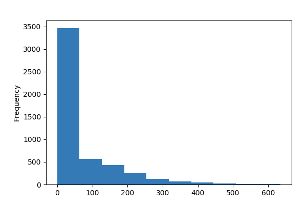

**Common Values**

| Value | Count | Frequency (%) |  |
| --- | --- | --- | --- |
| 0 | 3462 | 69.2% |  |
| 98 | 17 | 0.3% |  |
| 103 | 16 | 0.3% |  |
| 119 | 16 | 0.3% |  |
| 83 | 16 | 0.3% |  |
| 91 | 16 | 0.3% |  |
| 89 | 16 | 0.3% |  |
| 90 | 15 | 0.3% |  |
| 102 | 15 | 0.3% |  |
| 78 | 15 | 0.3% |  |
| Other values (337) | 1396 | 27.9% |  |

**Extreme Values**

Minimum 5 values

| Value | Count | Frequency (%) |  |
| --- | --- | --- | --- |
| 0 | 3462 | 69.2% |  |
| 75 | 8 | 0.2% |  |
| 76 | 12 | 0.2% |  |
| 77 | 4 | 0.1% |  |
| 78 | 15 | 0.3% |  |

Maximum 5 values

| Value | Count | Frequency (%) |  |
| --- | --- | --- | --- |
| 590 | 1 | 0.0% |  |
| 601 | 1 | 0.0% |  |
| 612 | 1 | 0.0% |  |
| 617 | 1 | 0.0% |  |
| 635 | 1 | 0.0% |  |

Personal Loan  
Boolean

| Distinct count | 2 |
| --- | --- |
| Unique (%) | 0.0% |
| Missing (%) | 0.0% |
| Missing (n) | 0 |

| Mean | 0.096 |
| --- | --- |

| 0 | 4520 |
| --- | --- |
| 1 | 480 |

Toggle details

| Value | Count | Frequency (%) |  |
| --- | --- | --- | --- |
| 0 | 4520 | 90.4% |  |
| 1 | 480 | 9.6% |  |

Securities Account  
Boolean

| Distinct count | 2 |
| --- | --- |
| Unique (%) | 0.0% |
| Missing (%) | 0.0% |
| Missing (n) | 0 |

| Mean | 0.1044 |
| --- | --- |

| 0 | 4478 |
| --- | --- |
| 1 | 522 |

Toggle details

| Value | Count | Frequency (%) |  |
| --- | --- | --- | --- |
| 0 | 4478 | 89.6% |  |
| 1 | 522 | 10.4% |  |

CD Account  
Boolean

| Distinct count | 2 |
| --- | --- |
| Unique (%) | 0.0% |
| Missing (%) | 0.0% |
| Missing (n) | 0 |

| Mean | 0.0604 |
| --- | --- |

| 0 | 4698 |
| --- | --- |
| 1 | 302 |

Toggle details

| Value | Count | Frequency (%) |  |
| --- | --- | --- | --- |
| 0 | 4698 | 94.0% |  |
| 1 | 302 | 6.0% |  |

Online  
Boolean

| Distinct count | 2 |
| --- | --- |
| Unique (%) | 0.0% |
| Missing (%) | 0.0% |
| Missing (n) | 0 |

| Mean | 0.5968 |
| --- | --- |

| 1 | 2984 |
| --- | --- |
| 0 | 2016 |

Toggle details

| Value | Count | Frequency (%) |  |
| --- | --- | --- | --- |
| 1 | 2984 | 59.7% |  |
| 0 | 2016 | 40.3% |  |

CreditCard  
Boolean

| Distinct count | 2 |
| --- | --- |
| Unique (%) | 0.0% |
| Missing (%) | 0.0% |
| Missing (n) | 0 |

| Mean | 0.294 |
| --- | --- |

| 0 | 3530 |
| --- | --- |
| 1 | 1470 |

Toggle details

| Value | Count | Frequency (%) |  |
| --- | --- | --- | --- |
| 0 | 3530 | 70.6% |  |
| 1 | 1470 | 29.4% |  |

Correlations

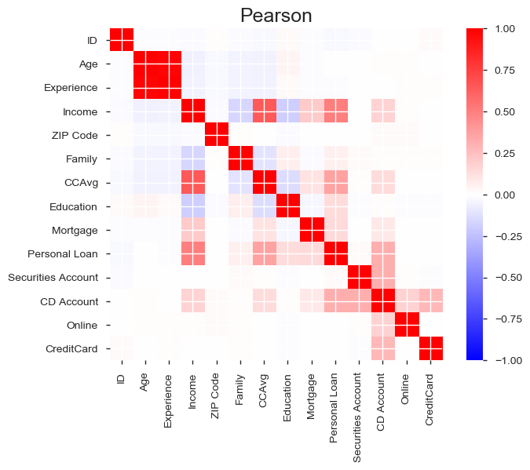

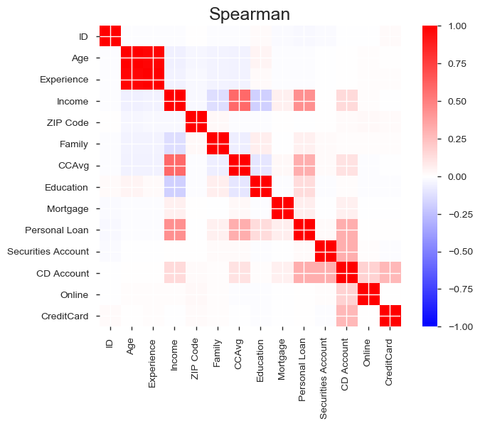

Sample

|  | ID | Age | Experience | Income | ZIP Code | Family | CCAvg | Education | Mortgage | Personal Loan | Securities Account | CD Account | Online | CreditCard |
| --- | --- | --- | --- | --- | --- | --- | --- | --- | --- | --- | --- | --- | --- | --- |
| 0 | 1 | 25 | 1.0 | 49 | 91107 | 4 | 1.6 | 1 | 0 | 0 | 1 | 0 | 0 | 0 |
| 1 | 2 | 45 | 19.0 | 34 | 90089 | 3 | 1.5 | 1 | 0 | 0 | 1 | 0 | 0 | 0 |
| 2 | 3 | 39 | 15.0 | 11 | 94720 | 1 | 1.0 | 1 | 0 | 0 | 0 | 0 | 0 | 0 |
| 3 | 4 | 35 | 9.0 | 100 | 94112 | 1 | 2.7 | 2 | 0 | 0 | 0 | 0 | 0 | 0 |
| 4 | 5 | 35 | 8.0 | 45 | 91330 | 4 | 1.0 | 2 | 0 | 0 | 0 | 0 | 0 | 1 |

```python
# 5. Univariate and Bivariate
#Univariate
from pandas_profiling import ProfileReport
ProfileReport(loanData)
```

# Above report provides following univariate analysis

Dataset info

1. Number of variables 14
2. Number of observations 5000
3. Total Missing (%) 0.0%
4. Total size in memory 547.0 KiB
5. Average record size in memory 112.0 B
6. Variables types
7. Numeric 8
8. Categorical 0
9. Boolean 5
10. Date 0
11. Text (Unique) 0
12. Rejected 1
13. Unsupported 0

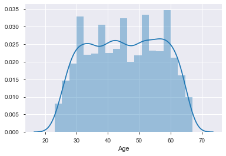

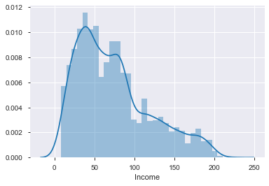

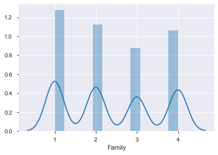

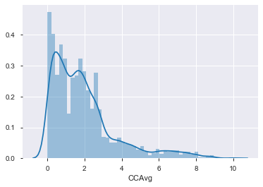

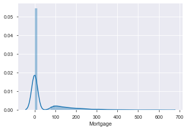

```python
for i in ['Age','Income','Family','CCAvg','Mortgage']:
    sns.distplot(loanData[i])
    plt.show()
```

```python
#Bivariate
corr = loanData.corr()
```

```python
c1= corr.unstack().sort_values(ascending = False)
c1.head(40)
```

```
CreditCard          CreditCard            1.000000
Online              Online                1.000000
Age                 Age                   1.000000
Experience          Experience            1.000000
Income              Income                1.000000
ZIP Code            ZIP Code              1.000000
Family              Family                1.000000
CCAvg               CCAvg                 1.000000
Education           Education             1.000000
Mortgage            Mortgage              1.000000
Personal Loan       Personal Loan         1.000000
Securities Account  Securities Account    1.000000
CD Account          CD Account            1.000000
ID                  ID                    1.000000
Age                 Experience            0.994215
Experience          Age                   0.994215
Income              CCAvg                 0.645984
CCAvg               Income                0.645984
Income              Personal Loan         0.502462
Personal Loan       Income                0.502462
CCAvg               Personal Loan         0.366889
Personal Loan       CCAvg                 0.366889
Securities Account  CD Account            0.317034
CD Account          Securities Account    0.317034
                    Personal Loan         0.316355
Personal Loan       CD Account            0.316355
CD Account          CreditCard            0.278644
CreditCard          CD Account            0.278644
Income              Mortgage              0.206806
Mortgage            Income                0.206806
CD Account          Online                0.175880
Online              CD Account            0.175880
Income              CD Account            0.169738
CD Account          Income                0.169738
Personal Loan       Mortgage              0.142095
Mortgage            Personal Loan         0.142095
Personal Loan       Education             0.136722
Education           Personal Loan         0.136722
CD Account          CCAvg                 0.136534
CCAvg               CD Account            0.136534
dtype: float64
```

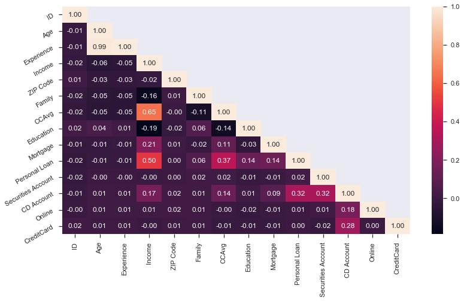

```python
sns.set_context("notebook", font_scale=1.0, rc={"lines.linewidth": 2.5})
plt.figure(figsize=(13,7))
# create a mask so we only see the correlation values once
mask = np.zeros_like(corr)
mask[np.triu_indices_from(mask, 1)] = True
a = sns.heatmap(corr,mask=mask, annot=True, fmt='.2f')
rotx = a.set_xticklabels(a.get_xticklabels(), rotation=90)
roty = a.set_yticklabels(a.get_yticklabels(), rotation=30)
```

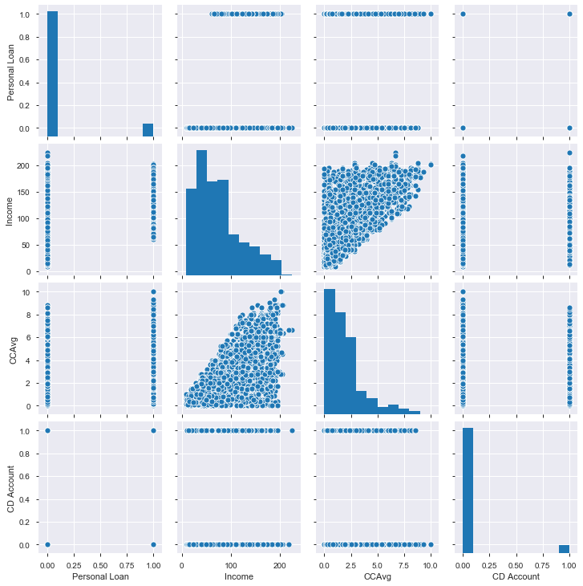

```python
sns.pairplot(loanData[['Personal Loan','Income','CCAvg','CD Account']])
```

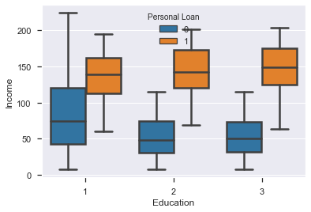

```python
sns.boxplot(x='Education',y='Income',hue='Personal Loan',data=loanData)
```

```python
pd.crosstab(loanData['Personal Loan'],loanData['Education'])
```

| Education Personal Loan | 1 | 2 | 3 |
| --- | --- | --- | --- |
| 0 | 2003 | 1221 | 1296 |
| 1 | 93 | 182 | 205 |

# Advanced/Professional are more likely to go for personal loan

```python
pd.crosstab(loanData['Personal Loan'],loanData['Family'])
```

| Family Personal Loan | 1 | 2 | 3 | 4 |
| --- | --- | --- | --- | --- |
| 0 | 1365 | 1190 | 877 | 1088 |
| 1 | 107 | 106 | 133 | 134 |

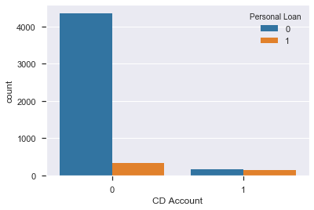

```python
sns.countplot(x='CD Account',data=loanData,hue='Personal Loan')
```

# Bivariate Analysis Summary:

# 6. Get data model ready

```python
# Correlation between Zip code and Personal Loan is very low.
# ID column does not add any value so dropping non-value adding columns
newData = loanData.drop('ZIP Code',axis = 1)
newData = loanData.drop('ID',axis = 1)
newData.head()
```

[output not shown]

# 3. Split the data into training and test set in the ratio of 70:30 respectively (5 marks)

```python
X = newData.drop('Personal Loan',axis=1)
Y = newData['Personal Loan']
```

```python
X = pd.get_dummies(X, drop_first=True)
```

```python
x_train, x_test, y_train, y_test = train_test_split(X, Y, test_size=0.3, random_state=1)
```

```python
print("Total records: ", len(loanData.index))
print("Training records: ", len(x_train))
print("Testing records: ",len(x_test))
```

```
Total records:  5000
Training records:  3500
Testing records:  1500
```

```python
print("{0:0.2f}% data is in training set".format((len(x_train)/len(loanData.index)) * 100))
print("{0:0.2f}% data is in test set".format((len(x_test)/len(loanData.index)) * 100))
```

```
70.00% data is in training set
30.00% data is in test set
```

# 4. Use Logistic Regression model to predict whether the customer will take personal loan or not. Print all the metrics related for evaluating the model performance (15 marks)

```python
# Fit the model on train
model = LogisticRegression(random_state=42,max_iter=5000)
model.fit(x_train, y_train)
```

```
LogisticRegression(C=1.0, class_weight=None, dual=False, fit_intercept=True,
                   intercept_scaling=1, l1_ratio=None, max_iter=5000,
                   multi_class='auto', n_jobs=None, penalty='l2',
                   random_state=42, solver='lbfgs', tol=0.0001, verbose=0,
                   warm_start=False)
```

```python
#predict on test
y_predict = model.predict(x_test)


coef_df = pd.DataFrame(model.coef_)
coef_df['intercept'] = model.intercept_
print(coef_df)
```

```
          0         1        2         3         4         5         6  \
0 -0.000451 -0.000425  0.03631 -0.000065  0.000172  0.001108  0.000227

          7         8         9        10        11  intercept
0  0.000851  0.000009  0.000141  0.000012  0.000005  -0.000001
```

```python
def draw_cm( actual, predicted ):
    cm = metrics.confusion_matrix( actual, predicted)
    sns.heatmap(cm, annot=True,fmt='.2f', xticklabels = [0,1] , yticklabels = [0,1] )
    plt.ylabel('Observed')
    plt.xlabel('Predicted')
    plt.show()
```

```
Training accuracy : 0.908

Testing accuracy: 0.908

Confusion Matrix
```

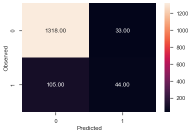

```
None

Recall: 0.2953020134228188

Precision: 0.5714285714285714

F1 Score: 0.3893805309734513

Roc Auc Score: 0.6354378312857988

Classification Report:
              precision    recall  f1-score   support

           0       0.93      0.98      0.95      1351
           1       0.57      0.30      0.39       149

    accuracy                           0.91      1500
   macro avg       0.75      0.64      0.67      1500
weighted avg       0.89      0.91      0.89      1500
```

```python
print("Training accuracy :",round(model.score(x_train, y_train),3))
print()
print("Testing accuracy:",round(model.score(x_test, y_test),3))
print()
print('Confusion Matrix')
print(draw_cm(y_test,y_predict))
print()
print("Recall:",recall_score(y_test,y_predict))
print()
print("Precision:",precision_score(y_test,y_predict))
print()
print("F1 Score:",f1_score(y_test,y_predict))
print()
print("Roc Auc Score:",roc_auc_score(y_test,y_predict))
print()
print("Classification Report:")
print(classification_report(y_test,y_predict))
```

# 5. Give your reasoning on how can the model perform better? (10 marks) Hint: Check parameter

# if the objective is to predict whether the customer will take personal loan or not, we need to reduce False Negatives. We need to look at recall along with accuracy.

```python
# different solvers

recall_values =[]
train_score=[]
test_score=[]
solver = ['newton-cg','lbfgs','liblinear','sag','saga']

for i in solver:
    model = LogisticRegression(random_state=42,penalty='l2', C = 0.75,solver=i,max_iter=5000)  # changing values of solver
    model.fit(x_train, y_train)
    model_predict = model.predict(x_test)
    recall_values.append(recall_score(y_test,model_predict))
    train_score.append(round(model.score(x_train, y_train),3))
    test_score.append(round(model.score(x_test, y_test),3))

print("Solver: ", solver)
print()
print("Recall: ", recall_values)
print()
print("Train Score: ",train_score)
print()
print("Test Score: ",test_score)
```

[output not shown]

```
Solver:  ['newton-cg', 'lbfgs', 'liblinear', 'sag', 'saga']

Recall:  [0.5704697986577181, 0.2953020134228188, 0.28859060402684567, 0.10067114093959731, 0.04697986577181208]

Train Score:  [0.952, 0.908, 0.909, 0.906, 0.907]

Test Score:  [0.947, 0.908, 0.907, 0.901, 0.903]
```

```python
#. Using Scaler to avoid ConvergenceWarning
from sklearn import preprocessing

loanData_columns = loanData.columns
scaler = preprocessing.StandardScaler()
scaled_x_train = scaler.fit_transform(x_train)
scaled_x_test = scaler.fit_transform(x_test)
```

```python
recall_values =[]
train_score=[]
test_score=[]
solver = ['newton-cg','lbfgs','liblinear','sag','saga']

for i in solver:
    model = LogisticRegression(random_state=42,penalty='l2', C = 0.75,solver=i,max_iter=5000)  # changing values of solver
    model.fit(scaled_x_train, y_train)
    model_predict = model.predict(scaled_x_test)
    recall_values.append(recall_score(y_test,model_predict))
    train_score.append(round(model.score(scaled_x_train, y_train),3))
    test_score.append(round(model.score(scaled_x_test, y_test),3))

print("Solver: ", solver)
print()
print("Recall: ", recall_values)
print()
print("Train Score: ",train_score)
print()
print("Test Score: ",test_score)
```

```
Solver:  ['newton-cg', 'lbfgs', 'liblinear', 'sag', 'saga']

Recall:  [0.5906040268456376, 0.5906040268456376, 0.5906040268456376, 0.5906040268456376, 0.5906040268456376]

Train Score:  [0.953, 0.953, 0.953, 0.953, 0.953]

Test Score:  [0.947, 0.947, 0.947, 0.947, 0.947]
```

# Recall is better with Scaler

```python
recall_values=[]
train_score=[]
test_score=[]
solver = ['liblinear','saga']   # changing values of solver which works with 'l1'
for i in solver:
    model = LogisticRegression(random_state=42,penalty='l1', C = 0.75,solver=i,max_iter=5000)  #changed penalty to 'l1'
    model.fit(scaled_x_train, y_train)
    model_predict = model.predict(scaled_x_test)
    recall_values.append(recall_score(y_test,model_predict))
    train_score.append(round(model.score(scaled_x_train, y_train),3))
    test_score.append(round(model.score(scaled_x_test, y_test),3))

print("Solver: ", solver)
print()
print("F1 Score: ", recall_values)
print()
print("Train Score: ",train_score)
print()
print("Test Score: ",test_score)
```

```
Solver:  ['liblinear', 'saga']

F1 Score:  [0.5973154362416108, 0.5973154362416108]

Train Score:  [0.953, 0.953]

Test Score:  [0.949, 0.949]
```

```python
# Accuracy and Recall are better with Scaler. It is almost same for every solver.

# We can use liblinear with L1 penalty

model = LogisticRegression(random_state=42,penalty='l1', solver='liblinear',max_iter=5000)
model.fit(scaled_x_train, y_train)
model_predict = model.predict(scaled_x_test)
bestRecallScore = recall_score(y_test,model_predict)
bestF1Score = f1_score(y_test,model_predict)
bestPrecisionScore = precision_score(y_test,model_predict)
bestTrainScore = round(model.score(scaled_x_train, y_train),3)
bestTestScore = round(model.score(scaled_x_test, y_test),3)


print("Recall Score",bestRecallScore)
print("F1 score",bestF1Score)
print("Precision ",bestPrecisionScore)
print("Train Score: ",bestTrainScore)
print("Test Score: ",bestTestScore)
```

```
Recall Score 0.5973154362416108
F1 score 0.6980392156862745
Precision  0.839622641509434
Train Score:  0.953
Test Score:  0.949
```

```python
# Now use balanced class_weight

model = LogisticRegression(random_state=42,penalty='l1', solver='liblinear',class_weight='balanced',max_iter=5000)
model.fit(scaled_x_train, y_train)
model_predict = model.predict(scaled_x_test)
bestRecallScore = recall_score(y_test,model_predict)
bestF1Score = f1_score(y_test,model_predict)
bestPrecisionScore = precision_score(y_test,model_predict)
bestTrainScore = round(model.score(scaled_x_train, y_train),3)
bestTestScore = round(model.score(scaled_x_test, y_test),3)


print("Recall Score",bestRecallScore)
print("F1 score",bestF1Score)
print("Precision ",bestPrecisionScore)
print("Train Score: ",bestTrainScore)
print("Test Score: ",bestTestScore)

# Only Recall is increased with balanced class_weight but not other parameters so not going to use balanced class_weight
```

```
Recall Score 0.8657718120805369
F1 score 0.6113744075829385
Precision  0.4725274725274725
Train Score:  0.899
Test Score:  0.891
```

```python
# different values of C
recall_values=[]
train_score=[]
test_score=[]
C = [0.01,0.1,0.25,0.5,0.75,1]
for i in C:
    model = LogisticRegression(random_state=42,penalty='l1', solver='liblinear',C=i,max_iter=5000)
    model.fit(scaled_x_train, y_train)
    model_predict = model.predict(scaled_x_test)
    recall_values.append(recall_score(y_test,model_predict))
    train_score.append(round(model.score(scaled_x_train, y_train),3))
    test_score.append(round(model.score(scaled_x_test, y_test),3))


print(C)
print()
print(recall_values)
print()
print("Train Score: ",train_score)
print()
print("Test Score: ",test_score)

# same result for 0.5,0.75,1 values for C
```

```
[0.01, 0.1, 0.25, 0.5, 0.75, 1]

[0.3422818791946309, 0.5503355704697986, 0.5771812080536913, 0.5973154362416108, 0.5973154362416108, 0.5973154362416108]

Train Score:  [0.934, 0.949, 0.952, 0.953, 0.953, 0.953]

Test Score:  [0.933, 0.947, 0.947, 0.949, 0.949, 0.949]
```

```
Training accuracy:  0.9531428571428572

Testing accuracy:  0.9486666666666667

Confusion Matrix
```

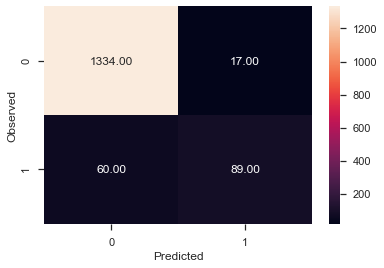

```
None

Recall: 0.5973154362416108

Precision: 0.839622641509434

F1 Score: 0.6980392156862745

Roc Auc Score: 0.7923660822954909
```

```python
#Therefore final model is
model = LogisticRegression(random_state=42,penalty='l1', solver='liblinear',C= 0.75,max_iter=5000)
model.fit(scaled_x_train, y_train)
model_predict = model.predict(scaled_x_test)


print("Training accuracy: ",model.score(scaled_x_train,y_train))
print()
print("Testing accuracy: ",model.score(scaled_x_test, y_test))
print()
print('Confusion Matrix')
print(draw_cm(y_test,model_predict))
print()
print("Recall:",recall_score(y_test,model_predict))
print()
print("Precision:",precision_score(y_test,model_predict))
print()
print("F1 Score:",f1_score(y_test,model_predict))
print()
print("Roc Auc Score:",roc_auc_score(y_test,model_predict))
```

# 6. Give Business understanding of your model? (5 marks)

The objective of this excercise is to predict whether the customer will take personal loan or not.

Since we are interested in the customers who had actually bought personal loans, but our model predicted that they will not buy loan. so the goal is to reduce False Negatives. Looking at our confusion matrix, we need to look at recall performance parameter along with accuracy.

Looking at exploratory data analysis, the 'Income', 'CCAvg' and 'Education' information seems to be more significant for deciding personal loan.

We performed following steps to improve model performance

1. Use Scaled Data
2. Experiment with differnet solvers
3. Change max_iter (This may cause performance delay in real world application but did not cause significant problem for our case)
4. Experiment with C values

Our final model includes

1. Scaled Data
2. solver='liblinear'
3. penalty='l1'
4. max_iter=5000
5. C=0.75

One observation is that the 'Training accuracy' is slightly better than 'Testing accuracy'. This may indicate overfitting of the model but same is observed with different parameters.